# mah_justin-13290085-week3

```python
# import packages
import pandas as pd
import numpy as np
import seaborn as sns
import matplotlib.pyplot as plt
from sklearn.metrics import roc_auc_score
from sklearn.preprocessing import StandardScaler
```

## Importing the data

```python
#import the data

train = pd.read_csv("/Users/justin_mah/Downloads/uts-advdsi-22-02-nba-career-prediction/train.csv")
test = pd.read_csv("/Users/justin_mah/Downloads/uts-advdsi-22-02-nba-career-prediction/test.csv")
```

```python
# observe the shape of the train data
train.shape
```

```
(8000, 21)
```

```python
# observe the shape of the test data
test.shape
```

```
(3799, 20)
```

```python
train.info()
```

```
<class 'pandas.core.frame.DataFrame'>
RangeIndex: 8000 entries, 0 to 7999
Data columns (total 21 columns):
 #   Column       Non-Null Count  Dtype
---  ------       --------------  -----
 0   Id           8000 non-null   int64
 1   GP           8000 non-null   int64
 2   MIN          8000 non-null   float64
 3   PTS          8000 non-null   float64
 4   FGM          8000 non-null   float64
 5   FGA          8000 non-null   float64
 6   FG%          8000 non-null   float64
 7   3P Made      8000 non-null   float64
 8   3PA          8000 non-null   float64
 9   3P%          8000 non-null   float64
 10  FTM          8000 non-null   float64
 11  FTA          8000 non-null   float64
 12  FT%          8000 non-null   float64
 13  OREB         8000 non-null   float64
 14  DREB         8000 non-null   float64
 15  REB          8000 non-null   float64
 16  AST          8000 non-null   float64
 17  STL          8000 non-null   float64
 18  BLK          8000 non-null   float64
 19  TOV          8000 non-null   float64
 20  TARGET_5Yrs  8000 non-null   int64
dtypes: float64(18), int64(3)
memory usage: 1.3 MB
```

```python
test.info()
```

```
<class 'pandas.core.frame.DataFrame'>
RangeIndex: 3799 entries, 0 to 3798
Data columns (total 20 columns):
 #   Column   Non-Null Count  Dtype
---  ------   --------------  -----
 0   Id       3799 non-null   int64
 1   GP       3799 non-null   int64
 2   MIN      3799 non-null   float64
 3   PTS      3799 non-null   float64
 4   FGM      3799 non-null   float64
 5   FGA      3799 non-null   float64
 6   FG%      3799 non-null   float64
 7   3P Made  3799 non-null   float64
 8   3PA      3799 non-null   float64
 9   3P%      3799 non-null   float64
 10  FTM      3799 non-null   float64
 11  FTA      3799 non-null   float64
 12  FT%      3799 non-null   float64
 13  OREB     3799 non-null   float64
 14  DREB     3799 non-null   float64
 15  REB      3799 non-null   float64
 16  AST      3799 non-null   float64
 17  STL      3799 non-null   float64
 18  BLK      3799 non-null   float64
 19  TOV      3799 non-null   float64
dtypes: float64(18), int64(2)
memory usage: 593.7 KB
```

## **Data Glossary**

Id_old - Previous Player Identifier (apparently not in data)

Id - Player Identifier

GP - Games Played

MIN - Minutes Played

PTS - Points Per Game

FGM - Field Goals Made

FGA - Field Goals Attempts

FG% - Field Goals Percent

3P Made - 3-Points Made

3PA - 3-Points Attempts

3P% - 3-Points Percent

FTM - Free Throw Made

FTA - Free Throw Attempts

FT% - Free Throw Percent

OREB - Offensive Rebounds

DREB - Defensive Rebounds

REB - Rebounds

AST - Assists

STL - Steals

BLK - Blocks

TOV - Turnovers

TARGET_5Yrs - Outcome: 1 if career length >= 5 years, 0 otherwise

```python
# identifying if there is any null values for each feature
test.isnull().sum()
```

```
Id         0
GP         0
MIN        0
PTS        0
FGM        0
FGA        0
FG%        0
3P Made    0
3PA        0
3P%        0
FTM        0
FTA        0
FT%        0
OREB       0
DREB       0
REB        0
AST        0
STL        0
BLK        0
TOV        0
dtype: int64
```

## Correlation Plot

Using the train dataset to check any association with the Target variable "TARGET_5Yrs" to the predictor variables.

```python
# This is another Correlation plot I preferred this one as it does give a lot more information
corr = train.corr()
corr.style.background_gradient(cmap='coolwarm')
```

|  | Id | GP | MIN | PTS | FGM | FGA | FG% | 3P Made | 3PA | 3P% | FTM | FTA | FT% | OREB | DREB | REB | AST | STL | BLK | TOV | TARGET_5Yrs |
| --- | --- | --- | --- | --- | --- | --- | --- | --- | --- | --- | --- | --- | --- | --- | --- | --- | --- | --- | --- | --- | --- |
| Id | 1.000000 | 0.028860 | 0.027481 | 0.023416 | 0.023845 | 0.024341 | 0.009777 | 0.008947 | 0.009524 | -0.005559 | 0.020854 | 0.017460 | 0.018887 | 0.014007 | 0.018180 | 0.018471 | 0.017703 | 0.007974 | 0.011955 | 0.021505 | 0.018233 |
| GP | 0.028860 | 1.000000 | 0.608090 | 0.578344 | 0.577697 | 0.553374 | 0.278510 | 0.123231 | 0.119146 | 0.045434 | 0.524276 | 0.519154 | 0.155667 | 0.402654 | 0.492070 | 0.484485 | 0.402126 | 0.473409 | 0.187269 | 0.537821 | 0.242108 |
| MIN | 0.027481 | 0.608090 | 1.000000 | 0.904840 | 0.895957 | 0.895085 | 0.234919 | 0.358597 | 0.372454 | 0.153846 | 0.767647 | 0.753660 | 0.212366 | 0.542782 | 0.770128 | 0.728842 | 0.639013 | 0.759933 | 0.260428 | 0.792059 | 0.182203 |
| PTS | 0.023416 | 0.578344 | 0.904840 | 1.000000 | 0.989208 | 0.973297 | 0.301991 | 0.337786 | 0.349452 | 0.156044 | 0.864463 | 0.842903 | 0.257157 | 0.539289 | 0.690687 | 0.673621 | 0.573893 | 0.678514 | 0.232923 | 0.816414 | 0.182004 |
| FGM | 0.023845 | 0.577697 | 0.895957 | 0.989208 | 1.000000 | 0.972670 | 0.343140 | 0.288906 | 0.299300 | 0.123230 | 0.810273 | 0.798366 | 0.208038 | 0.565086 | 0.699456 | 0.689229 | 0.550682 | 0.663419 | 0.245199 | 0.799119 | 0.183568 |
| FGA | 0.024341 | 0.553374 | 0.895085 | 0.973297 | 0.972670 | 1.000000 | 0.140998 | 0.373362 | 0.399025 | 0.203040 | 0.787989 | 0.761174 | 0.263515 | 0.464325 | 0.635072 | 0.607930 | 0.619597 | 0.689391 | 0.191895 | 0.816810 | 0.162389 |
| FG% | 0.009777 | 0.278510 | 0.234919 | 0.301991 | 0.343140 | 0.140998 | 1.000000 | -0.269994 | -0.330586 | -0.312446 | 0.279252 | 0.335512 | -0.187200 | 0.539317 | 0.429142 | 0.490902 | -0.132006 | 0.071364 | 0.288155 | 0.128622 | 0.158858 |
| 3P Made | 0.008947 | 0.123231 | 0.358597 | 0.337786 | 0.288906 | 0.373362 | -0.269994 | 1.000000 | 0.979340 | 0.585280 | 0.149567 | 0.088516 | 0.320845 | -0.200575 | 0.076694 | -0.014098 | 0.375967 | 0.305817 | -0.094750 | 0.231413 | 0.015016 |
| 3PA | 0.009524 | 0.119146 | 0.372454 | 0.349452 | 0.299300 | 0.399025 | -0.330586 | 0.979340 | 1.000000 | 0.576168 | 0.165116 | 0.101186 | 0.335011 | -0.213506 | 0.069782 | -0.023208 | 0.409646 | 0.337407 | -0.101143 | 0.255422 | 0.003463 |
| 3P% | -0.005559 | 0.045434 | 0.153846 | 0.156044 | 0.123230 | 0.203040 | -0.312446 | 0.585280 | 0.576168 | 1.000000 | 0.013036 | -0.054517 | 0.339894 | -0.297108 | -0.105370 | -0.181554 | 0.291623 | 0.195759 | -0.169376 | 0.095169 | -0.011977 |
| FTM | 0.020854 | 0.524276 | 0.767647 | 0.864463 | 0.810273 | 0.787989 | 0.279252 | 0.149567 | 0.165116 | 0.013036 | 1.000000 | 0.975611 | 0.274606 | 0.544742 | 0.619711 | 0.625154 | 0.486761 | 0.591616 | 0.221537 | 0.771939 | 0.173913 |
| FTA | 0.017460 | 0.519154 | 0.753660 | 0.842903 | 0.798366 | 0.761174 | 0.335512 | 0.088516 | 0.101186 | -0.054517 | 0.975611 | 1.000000 | 0.098091 | 0.616218 | 0.658778 | 0.678932 | 0.436225 | 0.572355 | 0.261547 | 0.762837 | 0.176525 |
| FT% | 0.018887 | 0.155667 | 0.212366 | 0.257157 | 0.208038 | 0.263515 | -0.187200 | 0.320845 | 0.335011 | 0.339894 | 0.274606 | 0.098091 | 1.000000 | -0.190785 | -0.042316 | -0.098987 | 0.306042 | 0.196138 | -0.150871 | 0.179152 | 0.039429 |
| OREB | 0.014007 | 0.402654 | 0.542782 | 0.539289 | 0.565086 | 0.464325 | 0.539317 | -0.200575 | -0.213506 | -0.297108 | 0.544742 | 0.616218 | -0.190785 | 1.000000 | 0.778602 | 0.897889 | -0.003037 | 0.290161 | 0.430952 | 0.378683 | 0.172604 |
| DREB | 0.018180 | 0.492070 | 0.770128 | 0.690687 | 0.699456 | 0.635072 | 0.429142 | 0.076694 | 0.069782 | -0.105370 | 0.619711 | 0.658778 | -0.042316 | 0.778602 | 1.000000 | 0.970105 | 0.223116 | 0.437507 | 0.441530 | 0.548209 | 0.168065 |
| REB | 0.018471 | 0.484485 | 0.728842 | 0.673621 | 0.689229 | 0.607930 | 0.490902 | -0.014098 | -0.023208 | -0.181554 | 0.625154 | 0.678932 | -0.098987 | 0.897889 | 0.970105 | 1.000000 | 0.149737 | 0.408584 | 0.458246 | 0.511051 | 0.175627 |
| AST | 0.017703 | 0.402126 | 0.639013 | 0.573893 | 0.550682 | 0.619597 | -0.132006 | 0.375967 | 0.409646 | 0.291623 | 0.486761 | 0.436225 | 0.306042 | -0.003037 | 0.223116 | 0.149737 | 1.000000 | 0.737032 | -0.084823 | 0.738581 | 0.096771 |
| STL | 0.007974 | 0.473409 | 0.759933 | 0.678514 | 0.663419 | 0.689391 | 0.071364 | 0.305817 | 0.337407 | 0.195759 | 0.591616 | 0.572355 | 0.196138 | 0.290161 | 0.437507 | 0.408584 | 0.737032 | 1.000000 | 0.095003 | 0.707753 | 0.128381 |
| BLK | 0.011955 | 0.187269 | 0.260428 | 0.232923 | 0.245199 | 0.191895 | 0.288155 | -0.094750 | -0.101143 | -0.169376 | 0.221537 | 0.261547 | -0.150871 | 0.430952 | 0.441530 | 0.458246 | -0.084823 | 0.095003 | 1.000000 | 0.144671 | 0.098642 |
| TOV | 0.021505 | 0.537821 | 0.792059 | 0.816414 | 0.799119 | 0.816810 | 0.128622 | 0.231413 | 0.255422 | 0.095169 | 0.771939 | 0.762837 | 0.179152 | 0.378683 | 0.548209 | 0.511051 | 0.738581 | 0.707753 | 0.144671 | 1.000000 | 0.151240 |
| TARGET_5Yrs | 0.018233 | 0.242108 | 0.182203 | 0.182004 | 0.183568 | 0.162389 | 0.158858 | 0.015016 | 0.003463 | -0.011977 | 0.173913 | 0.176525 | 0.039429 | 0.172604 | 0.168065 | 0.175627 | 0.096771 | 0.128381 | 0.098642 | 0.151240 | 1.000000 |

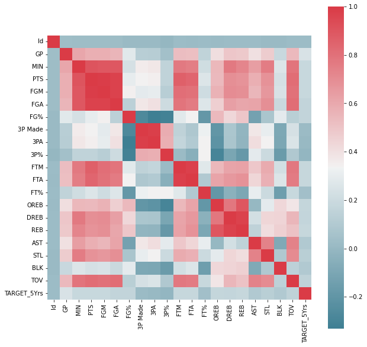

```python
# Sample of using a correlation plot to identify which feature is associated with our Target variable "TARGET_5Yrs"
import seaborn as sns
import matplotlib.pyplot as plt

f, ax = plt.subplots(figsize=(10, 10))
corr = train.corr()
sns.heatmap(corr, mask=np.zeros_like(corr, dtype=np.bool), cmap=sns.diverging_palette(220, 10, as_cmap=True),
            square=True, ax=ax)
```

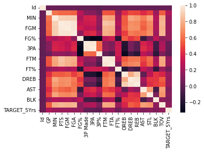

```python
# Seaborn heatmap correlation plot (insufficient visualisation to give information to client)
sns.heatmap(train.corr())
```

```python
# Adjusting the jupyter notebook display to see more data
pd.set_option('display.max_rows', 600)
pd.set_option('display.max_columns', 100)
pd.set_option('display.width', 500)
```

## *Lets examine the details of the dataset*

```python
# observing the first 5 records
train.head()
```

|  | Id | GP | MIN | PTS | FGM | FGA | FG% | 3P Made | 3PA | 3P% | FTM | FTA | FT% | OREB | DREB | REB | AST | STL | BLK | TOV | TARGET_5Yrs |
| --- | --- | --- | --- | --- | --- | --- | --- | --- | --- | --- | --- | --- | --- | --- | --- | --- | --- | --- | --- | --- | --- |
| 0 | 10556 | 80 | 24.3 | 7.8 | 3.0 | 6.4 | 45.7 | 0.1 | 0.3 | 22.6 | 2.0 | 2.9 | 72.1 | 2.2 | 2.0 | 3.8 | 3.2 | 1.1 | 0.2 | 1.6 | 1 |
| 1 | 5342 | 75 | 21.8 | 10.5 | 4.2 | 7.9 | 55.1 | -0.3 | -1.0 | 34.9 | 2.4 | 3.6 | 67.8 | 3.6 | 3.7 | 6.6 | 0.7 | 0.5 | 0.6 | 1.4 | 1 |
| 2 | 5716 | 85 | 19.1 | 4.5 | 1.9 | 4.5 | 42.8 | 0.4 | 1.2 | 34.3 | 0.4 | 0.6 | 75.7 | 0.6 | 1.8 | 2.4 | 0.8 | 0.4 | 0.2 | 0.6 | 1 |
| 3 | 13790 | 63 | 19.1 | 8.2 | 3.5 | 6.7 | 52.5 | 0.3 | 0.8 | 23.7 | 0.9 | 1.5 | 66.9 | 0.8 | 2.0 | 3.0 | 1.8 | 0.4 | 0.1 | 1.9 | 1 |
| 4 | 5470 | 63 | 17.8 | 3.7 | 1.7 | 3.4 | 50.8 | 0.5 | 1.4 | 13.7 | 0.2 | 0.5 | 54.0 | 2.4 | 2.7 | 4.9 | 0.4 | 0.4 | 0.6 | 0.7 | 1 |

```python
# the first 5 rows for test data
test.head()
```

|  | Id | GP | MIN | PTS | FGM | FGA | FG% | 3P Made | 3PA | 3P% | FTM | FTA | FT% | OREB | DREB | REB | AST | STL | BLK | TOV |
| --- | --- | --- | --- | --- | --- | --- | --- | --- | --- | --- | --- | --- | --- | --- | --- | --- | --- | --- | --- | --- |
| 0 | 1 | 56 | 9.1 | 4.0 | 1.6 | 3.7 | 43.7 | 0.1 | 0.3 | 7.3 | 0.7 | 1.2 | 63.4 | 1.2 | 0.8 | 1.7 | 0.4 | 0.2 | 0.3 | 0.8 |
| 1 | 8194 | 43 | 19.3 | 10.1 | 3.7 | 8.1 | 46.0 | 0.6 | 1.7 | 35.1 | 1.8 | 2.5 | 75.3 | 0.5 | 0.9 | 1.5 | 3.5 | 0.6 | -0.0 | 1.8 |
| 2 | 3 | 82 | 33.9 | 11.3 | 4.9 | 10.6 | 45.6 | 0.5 | 1.9 | 44.8 | 1.8 | 2.7 | 71.2 | 1.3 | 3.3 | 4.5 | 2.5 | 1.3 | 0.3 | 2.0 |
| 3 | 8196 | 86 | 44.7 | 18.8 | 6.8 | 15.9 | 42.9 | 0.5 | 1.8 | 13.5 | 4.5 | 6.3 | 70.9 | 1.5 | 3.2 | 5.0 | 4.1 | 0.9 | 0.1 | 3.6 |
| 4 | 8197 | 58 | 12.3 | 4.7 | 1.6 | 4.0 | 40.0 | 0.5 | 1.7 | 38.7 | 1.1 | 1.3 | 76.9 | 0.2 | 0.6 | 0.9 | 1.5 | 0.5 | -0.4 | 0.9 |

```python
# train.corr().plot()
# import matplotlib.pyplot as plt
# plt.matshow(train.corr())
# plt.show()
```

Check the **TARGET_5Yrs** variable only has 0 or 1.

```python
# Check Target variable to see the unique values in that column, should be only 1 or 0
train["TARGET_5Yrs"].unique()

# Thats great there is no artifacts in that column besides 1 and 0
```

```
array([1, 0])
```

### Produce a crosstab to show the data imbalance for target variable

```python
# Using crosstab function lets check the train data of the sum of the group
pd.crosstab(train['TARGET_5Yrs'],train['TARGET_5Yrs'],margins=True)
```

| TARGET_5Yrs | 0 | 1 | All |
| --- | --- | --- | --- |
| 0 | 1331 | 0 | 1331 |
| 1 | 0 | 6669 | 6669 |
| All | 1331 | 6669 | 8000 |

### --- **Lets look at NBA Rookies that have passed 5 years in the organisation** ---

```python
# create a filter dataframe with records only have passed 5 years in NBA and save it as 'passed'
passed = train[train['TARGET_5Yrs']==1]
passed
```

|  | Id | GP | MIN | PTS | FGM | FGA | FG% | 3P Made | 3PA | 3P% | FTM | FTA | FT% | OREB | DREB | REB | AST | STL | BLK | TOV | TARGET_5Yrs |
| --- | --- | --- | --- | --- | --- | --- | --- | --- | --- | --- | --- | --- | --- | --- | --- | --- | --- | --- | --- | --- | --- |
| 0 | 10556 | 80 | 24.3 | 7.8 | 3.0 | 6.4 | 45.7 | 0.1 | 0.3 | 22.6 | 2.0 | 2.9 | 72.1 | 2.2 | 2.0 | 3.8 | 3.2 | 1.1 | 0.2 | 1.6 | 1 |
| 1 | 5342 | 75 | 21.8 | 10.5 | 4.2 | 7.9 | 55.1 | -0.3 | -1.0 | 34.9 | 2.4 | 3.6 | 67.8 | 3.6 | 3.7 | 6.6 | 0.7 | 0.5 | 0.6 | 1.4 | 1 |
| 2 | 5716 | 85 | 19.1 | 4.5 | 1.9 | 4.5 | 42.8 | 0.4 | 1.2 | 34.3 | 0.4 | 0.6 | 75.7 | 0.6 | 1.8 | 2.4 | 0.8 | 0.4 | 0.2 | 0.6 | 1 |
| 3 | 13790 | 63 | 19.1 | 8.2 | 3.5 | 6.7 | 52.5 | 0.3 | 0.8 | 23.7 | 0.9 | 1.5 | 66.9 | 0.8 | 2.0 | 3.0 | 1.8 | 0.4 | 0.1 | 1.9 | 1 |
| 4 | 5470 | 63 | 17.8 | 3.7 | 1.7 | 3.4 | 50.8 | 0.5 | 1.4 | 13.7 | 0.2 | 0.5 | 54.0 | 2.4 | 2.7 | 4.9 | 0.4 | 0.4 | 0.6 | 0.7 | 1 |
| ... | ... | ... | ... | ... | ... | ... | ... | ... | ... | ... | ... | ... | ... | ... | ... | ... | ... | ... | ... | ... | ... |
| 7995 | 2996 | 32 | 9.2 | 1.8 | 0.7 | 1.8 | 40.3 | -0.1 | -0.2 | 23.1 | 0.4 | 0.6 | 65.7 | 0.3 | 1.8 | 1.9 | 0.5 | 0.3 | 0.2 | 0.4 | 1 |
| 7996 | 11679 | 54 | 6.0 | 1.8 | 0.7 | 1.4 | 48.7 | 0.1 | 0.1 | 3.1 | 0.2 | 0.4 | 70.1 | 1.0 | 1.1 | 2.0 | 0.1 | 0.0 | 0.3 | 0.3 | 1 |
| 7997 | 5537 | 85 | 28.2 | 10.7 | 4.0 | 9.0 | 45.1 | 0.2 | 0.6 | 23.6 | 2.8 | 3.9 | 69.7 | 1.0 | 2.1 | 3.1 | 3.4 | 1.2 | 0.2 | 1.8 | 1 |
| 7998 | 1292 | 39 | 7.7 | 2.5 | 1.0 | 2.3 | 40.1 | -0.3 | -0.5 | 13.3 | 0.6 | 0.7 | 74.3 | 0.4 | 0.6 | 0.9 | 0.2 | 0.3 | 0.3 | 0.5 | 1 |
| 7999 | 2900 | 49 | 19.2 | 4.8 | 1.7 | 5.1 | 32.6 | 0.7 | 2.4 | 41.3 | 0.8 | 1.3 | 70.1 | 0.1 | 1.1 | 1.2 | 3.5 | 0.9 | -0.3 | 1.4 | 1 |

6669 rows × 21 columns

```python
passed.describe()
```

|  | Id | GP | MIN | PTS | FGM | FGA | FG% | 3P Made | 3PA | 3P% | FTM | FTA | FT% | OREB | DREB | REB | AST | STL | BLK | TOV | TARGET_5Yrs |
| --- | --- | --- | --- | --- | --- | --- | --- | --- | --- | --- | --- | --- | --- | --- | --- | --- | --- | --- | --- | --- | --- |
| count | 6669.000000 | 6669.000000 | 6669.000000 | 6669.000000 | 6669.000000 | 6669.000000 | 6669.000000 | 6669.000000 | 6669.000000 | 6669.000000 | 6669.000000 | 6669.000000 | 6669.000000 | 6669.000000 | 6669.000000 | 6669.000000 | 6669.000000 | 6669.000000 | 6669.000000 | 6669.000000 | 6669.0 |
| mean | 6889.367971 | 64.629330 | 19.303929 | 7.618219 | 2.945899 | 6.491243 | 45.045719 | 0.267102 | 0.818204 | 19.498081 | 1.464477 | 2.046544 | 71.549543 | 1.138417 | 2.273024 | 3.408892 | 1.683131 | 0.672065 | 0.281392 | 1.306628 | 1.0 |
| std | 3971.261531 | 16.718539 | 9.069595 | 4.396696 | 1.726871 | 3.655725 | 6.093200 | 0.384559 | 1.062603 | 15.974117 | 0.939564 | 1.271339 | 10.469601 | 0.802867 | 1.419288 | 2.125565 | 1.386373 | 0.415717 | 0.766430 | 0.735796 | 0.0 |
| min | 4.000000 | -3.000000 | 3.300000 | 0.900000 | 0.300000 | 0.900000 | 21.300000 | -1.100000 | -2.600000 | -38.500000 | 0.000000 | 0.000000 | -13.300000 | 0.000000 | 0.200000 | 0.300000 | 0.000000 | 0.000000 | -15.700000 | 0.100000 | 1.0 |
| 25% | 3472.000000 | 53.000000 | 12.600000 | 4.400000 | 1.700000 | 3.800000 | 40.900000 | 0.000000 | 0.100000 | 8.200000 | 0.800000 | 1.100000 | 65.300000 | 0.500000 | 1.200000 | 1.800000 | 0.700000 | 0.400000 | 0.100000 | 0.800000 | 1.0 |
| 50% | 6793.000000 | 64.000000 | 17.600000 | 6.700000 | 2.600000 | 5.700000 | 44.900000 | 0.300000 | 0.800000 | 19.400000 | 1.300000 | 1.800000 | 71.500000 | 1.000000 | 2.000000 | 3.000000 | 1.300000 | 0.600000 | 0.200000 | 1.200000 | 1.0 |
| 75% | 10326.000000 | 76.000000 | 24.500000 | 9.900000 | 3.900000 | 8.400000 | 49.000000 | 0.500000 | 1.500000 | 30.600000 | 2.000000 | 2.700000 | 77.600000 | 1.500000 | 3.000000 | 4.500000 | 2.300000 | 0.900000 | 0.400000 | 1.700000 | 1.0 |
| max | 13798.000000 | 123.000000 | 73.800000 | 34.200000 | 13.100000 | 28.900000 | 67.200000 | 1.700000 | 4.700000 | 82.100000 | 8.100000 | 11.100000 | 168.900000 | 5.500000 | 11.000000 | 15.900000 | 12.800000 | 3.600000 | 18.900000 | 5.300000 | 1.0 |

```python
passed.info()
```

```
<class 'pandas.core.frame.DataFrame'>
Int64Index: 6669 entries, 0 to 7999
Data columns (total 21 columns):
 #   Column       Non-Null Count  Dtype
---  ------       --------------  -----
 0   Id           6669 non-null   int64
 1   GP           6669 non-null   int64
 2   MIN          6669 non-null   float64
 3   PTS          6669 non-null   float64
 4   FGM          6669 non-null   float64
 5   FGA          6669 non-null   float64
 6   FG%          6669 non-null   float64
 7   3P Made      6669 non-null   float64
 8   3PA          6669 non-null   float64
 9   3P%          6669 non-null   float64
 10  FTM          6669 non-null   float64
 11  FTA          6669 non-null   float64
 12  FT%          6669 non-null   float64
 13  OREB         6669 non-null   float64
 14  DREB         6669 non-null   float64
 15  REB          6669 non-null   float64
 16  AST          6669 non-null   float64
 17  STL          6669 non-null   float64
 18  BLK          6669 non-null   float64
 19  TOV          6669 non-null   float64
 20  TARGET_5Yrs  6669 non-null   int64
dtypes: float64(18), int64(3)
memory usage: 1.1 MB
```

```python
# Check correlation for passed and identify possible multicollinearity.
corr_pass = passed.corr()

corr_pass.style.background_gradient(cmap='coolwarm')
```

|  | Id | GP | MIN | PTS | FGM | FGA | FG% | 3P Made | 3PA | 3P% | FTM | FTA | FT% | OREB | DREB | REB | AST | STL | BLK | TOV | TARGET_5Yrs |
| --- | --- | --- | --- | --- | --- | --- | --- | --- | --- | --- | --- | --- | --- | --- | --- | --- | --- | --- | --- | --- | --- |
| Id | 1.000000 | 0.031239 | 0.029226 | 0.025308 | 0.025165 | 0.025797 | 0.005963 | 0.015010 | 0.015655 | -0.002916 | 0.023093 | 0.018008 | 0.028733 | 0.008833 | 0.013528 | 0.013281 | 0.021664 | 0.005362 | 0.011549 | 0.024401 | nan |
| GP | 0.031239 | 1.000000 | 0.595901 | 0.567392 | 0.566320 | 0.543503 | 0.252092 | 0.122282 | 0.119836 | 0.052079 | 0.511675 | 0.506110 | 0.149833 | 0.383911 | 0.477376 | 0.469142 | 0.397600 | 0.464152 | 0.184132 | 0.530314 | nan |
| MIN | 0.029226 | 0.595901 | 1.000000 | 0.902605 | 0.893831 | 0.893472 | 0.213058 | 0.360379 | 0.375442 | 0.163182 | 0.758825 | 0.744390 | 0.203574 | 0.529313 | 0.763939 | 0.721264 | 0.638752 | 0.757098 | 0.267505 | 0.790062 | nan |
| PTS | 0.025308 | 0.567392 | 0.902605 | 1.000000 | 0.988946 | 0.972870 | 0.283103 | 0.338871 | 0.351692 | 0.166221 | 0.859657 | 0.837407 | 0.249881 | 0.525673 | 0.681734 | 0.664041 | 0.571683 | 0.674623 | 0.236649 | 0.815005 | nan |
| FGM | 0.025165 | 0.566320 | 0.893831 | 0.988946 | 1.000000 | 0.972420 | 0.325236 | 0.289200 | 0.300874 | 0.132975 | 0.803660 | 0.791370 | 0.200427 | 0.551687 | 0.690864 | 0.680016 | 0.548625 | 0.660018 | 0.249691 | 0.796965 | nan |
| FGA | 0.025797 | 0.543503 | 0.893472 | 0.972870 | 0.972420 | 1.000000 | 0.119955 | 0.375197 | 0.401839 | 0.212116 | 0.781201 | 0.753770 | 0.256119 | 0.449336 | 0.625590 | 0.597311 | 0.618190 | 0.685995 | 0.192582 | 0.815165 | nan |
| FG% | 0.005963 | 0.252092 | 0.213058 | 0.283103 | 0.325236 | 0.119955 | 1.000000 | -0.286990 | -0.345988 | -0.309973 | 0.261764 | 0.319774 | -0.196717 | 0.533617 | 0.417362 | 0.482075 | -0.149835 | 0.054257 | 0.287961 | 0.110897 | nan |
| 3P Made | 0.015010 | 0.122282 | 0.360379 | 0.338871 | 0.289200 | 0.375197 | -0.286990 | 1.000000 | 0.979394 | 0.586433 | 0.146558 | 0.083979 | 0.319720 | -0.214986 | 0.068405 | -0.024501 | 0.380358 | 0.306578 | -0.101950 | 0.236519 | nan |
| 3PA | 0.015655 | 0.119836 | 0.375442 | 0.351692 | 0.300874 | 0.401839 | -0.345988 | 0.979394 | 1.000000 | 0.576910 | 0.162986 | 0.097779 | 0.331728 | -0.225878 | 0.063569 | -0.031537 | 0.413292 | 0.338448 | -0.106902 | 0.260900 | nan |
| 3P% | -0.002916 | 0.052079 | 0.163182 | 0.166221 | 0.132975 | 0.212116 | -0.309973 | 0.586433 | 0.576910 | 1.000000 | 0.019454 | -0.048588 | 0.339304 | -0.298515 | -0.101219 | -0.179650 | 0.291907 | 0.199994 | -0.166552 | 0.103976 | nan |
| FTM | 0.023093 | 0.511675 | 0.758825 | 0.859657 | 0.803660 | 0.781201 | 0.261764 | 0.146558 | 0.162986 | 0.019454 | 1.000000 | 0.974810 | 0.266920 | 0.534385 | 0.608965 | 0.615336 | 0.477776 | 0.581643 | 0.228368 | 0.766737 | nan |
| FTA | 0.018008 | 0.506110 | 0.744390 | 0.837407 | 0.791370 | 0.753770 | 0.319774 | 0.083979 | 0.097779 | -0.048588 | 0.974810 | 1.000000 | 0.086399 | 0.607682 | 0.649372 | 0.670939 | 0.426283 | 0.562862 | 0.269509 | 0.756500 | nan |
| FT% | 0.028733 | 0.149833 | 0.203574 | 0.249881 | 0.200427 | 0.256119 | -0.196717 | 0.319720 | 0.331728 | 0.339304 | 0.266920 | 0.086399 | 1.000000 | -0.200617 | -0.054457 | -0.111500 | 0.299266 | 0.186451 | -0.150081 | 0.172167 | nan |
| OREB | 0.008833 | 0.383911 | 0.529313 | 0.525673 | 0.551687 | 0.449336 | 0.533617 | -0.214986 | -0.225878 | -0.298515 | 0.534385 | 0.607682 | -0.200617 | 1.000000 | 0.771549 | 0.894786 | -0.015001 | 0.279436 | 0.450477 | 0.366935 | nan |
| DREB | 0.013528 | 0.477376 | 0.763939 | 0.681734 | 0.690864 | 0.625590 | 0.417362 | 0.068405 | 0.063569 | -0.101219 | 0.608965 | 0.649372 | -0.054457 | 0.771549 | 1.000000 | 0.969117 | 0.216266 | 0.430209 | 0.466353 | 0.542052 | nan |
| REB | 0.013281 | 0.469142 | 0.721264 | 0.664041 | 0.680016 | 0.597311 | 0.482075 | -0.024501 | -0.031537 | -0.179650 | 0.615336 | 0.670939 | -0.111500 | 0.894786 | 0.969117 | 1.000000 | 0.141201 | 0.400587 | 0.483531 | 0.503489 | nan |
| AST | 0.021664 | 0.397600 | 0.638752 | 0.571683 | 0.548625 | 0.618190 | -0.149835 | 0.380358 | 0.413292 | 0.291907 | 0.477776 | 0.426283 | 0.299266 | -0.015001 | 0.216266 | 0.141201 | 1.000000 | 0.738272 | -0.084851 | 0.737856 | nan |
| STL | 0.005362 | 0.464152 | 0.757098 | 0.674623 | 0.660018 | 0.685995 | 0.054257 | 0.306578 | 0.338448 | 0.199994 | 0.581643 | 0.562862 | 0.186451 | 0.279436 | 0.430209 | 0.400587 | 0.738272 | 1.000000 | 0.092878 | 0.705995 | nan |
| BLK | 0.011549 | 0.184132 | 0.267505 | 0.236649 | 0.249691 | 0.192582 | 0.287961 | -0.101950 | -0.106902 | -0.166552 | 0.228368 | 0.269509 | -0.150081 | 0.450477 | 0.466353 | 0.483531 | -0.084851 | 0.092878 | 1.000000 | 0.144592 | nan |
| TOV | 0.024401 | 0.530314 | 0.790062 | 0.815005 | 0.796965 | 0.815165 | 0.110897 | 0.236519 | 0.260900 | 0.103976 | 0.766737 | 0.756500 | 0.172167 | 0.366935 | 0.542052 | 0.503489 | 0.737856 | 0.705995 | 0.144592 | 1.000000 | nan |
| TARGET_5Yrs | nan | nan | nan | nan | nan | nan | nan | nan | nan | nan | nan | nan | nan | nan | nan | nan | nan | nan | nan | nan | nan |

### *Summary statistics*

```python
# Summary statistics for train data
train.describe()
```

|  | Id | GP | MIN | PTS | FGM | FGA | FG% | 3P Made | 3PA | 3P% | FTM | FTA | FT% | OREB | DREB | REB | AST | STL | BLK | TOV | TARGET_5Yrs |
| --- | --- | --- | --- | --- | --- | --- | --- | --- | --- | --- | --- | --- | --- | --- | --- | --- | --- | --- | --- | --- | --- |
| count | 8000.000000 | 8000.000000 | 8000.000000 | 8000.000000 | 8000.000000 | 8000.000000 | 8000.000000 | 8000.000000 | 8000.000000 | 8000.000000 | 8000.000000 | 8000.000000 | 8000.000000 | 8000.000000 | 8000.000000 | 8000.000000 | 8000.000000 | 8000.000000 | 8000.000000 | 8000.000000 | 8000.000000 |
| mean | 6856.971000 | 62.777875 | 18.576663 | 7.267087 | 2.807037 | 6.231213 | 44.608900 | 0.264525 | 0.816563 | 19.583700 | 1.392525 | 1.947787 | 71.365825 | 1.077838 | 2.168500 | 3.245300 | 1.624513 | 0.648688 | 0.245212 | 1.257762 | 0.833625 |
| std | 3977.447579 | 17.118774 | 8.935263 | 4.318732 | 1.693373 | 3.584559 | 6.155453 | 0.384093 | 1.060964 | 16.003155 | 0.926153 | 1.252352 | 10.430447 | 0.785670 | 1.392224 | 2.085154 | 1.355986 | 0.407626 | 0.821037 | 0.723270 | 0.372440 |
| min | 4.000000 | -8.000000 | 2.900000 | 0.800000 | 0.300000 | 0.800000 | 21.300000 | -1.100000 | -3.100000 | -38.500000 | 0.000000 | 0.000000 | -13.300000 | 0.000000 | 0.200000 | 0.300000 | 0.000000 | 0.000000 | -17.900000 | 0.100000 | 0.000000 |
| 25% | 3413.750000 | 51.000000 | 12.000000 | 4.100000 | 1.600000 | 3.600000 | 40.400000 | 0.000000 | 0.100000 | 8.400000 | 0.700000 | 1.000000 | 65.000000 | 0.500000 | 1.100000 | 1.700000 | 0.700000 | 0.300000 | 0.100000 | 0.700000 | 1.000000 |
| 50% | 6787.500000 | 63.000000 | 16.800000 | 6.300000 | 2.400000 | 5.400000 | 44.400000 | 0.300000 | 0.800000 | 19.500000 | 1.200000 | 1.700000 | 71.400000 | 0.900000 | 1.900000 | 2.800000 | 1.300000 | 0.600000 | 0.200000 | 1.100000 | 1.000000 |
| 75% | 10299.250000 | 74.000000 | 23.500000 | 9.500000 | 3.700000 | 8.100000 | 48.700000 | 0.500000 | 1.500000 | 30.600000 | 1.900000 | 2.600000 | 77.500000 | 1.500000 | 2.900000 | 4.300000 | 2.200000 | 0.900000 | 0.400000 | 1.600000 | 1.000000 |
| max | 13798.000000 | 123.000000 | 73.800000 | 34.200000 | 13.100000 | 28.900000 | 67.200000 | 1.700000 | 4.700000 | 82.100000 | 8.100000 | 11.100000 | 168.900000 | 5.500000 | 11.000000 | 15.900000 | 12.800000 | 3.600000 | 18.900000 | 5.300000 | 1.000000 |

```python
# Summary statistics for test data
test.describe()
```

|  | Id | GP | MIN | PTS | FGM | FGA | FG% | 3P Made | 3PA | 3P% | FTM | FTA | FT% | OREB | DREB | REB | AST | STL | BLK | TOV |
| --- | --- | --- | --- | --- | --- | --- | --- | --- | --- | --- | --- | --- | --- | --- | --- | --- | --- | --- | --- | --- |
| count | 3799.000000 | 3799.000000 | 3799.000000 | 3799.000000 | 3799.000000 | 3799.000000 | 3799.000000 | 3799.000000 | 3799.000000 | 3799.000000 | 3799.000000 | 3799.000000 | 3799.000000 | 3799.000000 | 3799.000000 | 3799.000000 | 3799.000000 | 3799.000000 | 3799.000000 | 3799.000000 |
| mean | 7010.614109 | 62.853909 | 18.650224 | 7.328034 | 2.835404 | 6.302580 | 44.599079 | 0.255962 | 0.796920 | 19.234746 | 1.399842 | 1.953567 | 71.612924 | 1.096025 | 2.179495 | 3.275783 | 1.636483 | 0.653593 | 0.257726 | 1.257910 |
| std | 3954.173641 | 17.151740 | 8.727259 | 4.294724 | 1.688427 | 3.579221 | 6.040168 | 0.380987 | 1.052862 | 15.968989 | 0.926140 | 1.250376 | 10.457336 | 0.785678 | 1.371935 | 2.070646 | 1.335496 | 0.410573 | 0.639660 | 0.712449 |
| min | 1.000000 | 6.000000 | 3.700000 | 0.700000 | 0.300000 | 0.800000 | 25.100000 | -1.000000 | -2.700000 | -38.000000 | 0.000000 | 0.000000 | 23.700000 | 0.000000 | 0.200000 | 0.300000 | 0.000000 | 0.000000 | -7.100000 | 0.100000 |
| 25% | 3644.000000 | 51.000000 | 12.200000 | 4.200000 | 1.600000 | 3.700000 | 40.500000 | 0.000000 | 0.100000 | 8.500000 | 0.700000 | 1.000000 | 65.000000 | 0.500000 | 1.200000 | 1.800000 | 0.600000 | 0.400000 | 0.100000 | 0.700000 |
| 50% | 7062.000000 | 63.000000 | 17.000000 | 6.400000 | 2.500000 | 5.500000 | 44.600000 | 0.300000 | 0.800000 | 19.400000 | 1.200000 | 1.700000 | 71.500000 | 0.900000 | 1.900000 | 2.800000 | 1.300000 | 0.600000 | 0.200000 | 1.100000 |
| 75% | 10402.500000 | 74.000000 | 23.300000 | 9.400000 | 3.700000 | 8.100000 | 48.500000 | 0.500000 | 1.500000 | 30.250000 | 1.900000 | 2.600000 | 78.000000 | 1.500000 | 2.900000 | 4.300000 | 2.300000 | 0.900000 | 0.400000 | 1.600000 |
| max | 13792.000000 | 126.000000 | 68.000000 | 33.000000 | 13.400000 | 26.200000 | 74.600000 | 1.600000 | 4.300000 | 73.800000 | 7.800000 | 9.800000 | 127.100000 | 6.900000 | 12.000000 | 18.500000 | 9.000000 | 2.700000 | 14.800000 | 5.200000 |

### Preparing the data

```python
# Create a copy of the train data
df = train.copy()

# Seperate the TARGET_5YRS column from df and naming it as "target"
target = df.pop('TARGET_5Yrs')
```

```python
# turn "Id" column as an index column
# df.set_index(df["Id"],inplace=True)
```

```python
# remove "Id" column in df
# df.drop(columns = ['Id'], inplace = True)
```

```python
# review df
df.head()
```

|  | Id | GP | MIN | PTS | FGM | FGA | FG% | 3P Made | 3PA | 3P% | FTM | FTA | FT% | OREB | DREB | REB | AST | STL | BLK | TOV |
| --- | --- | --- | --- | --- | --- | --- | --- | --- | --- | --- | --- | --- | --- | --- | --- | --- | --- | --- | --- | --- |
| 0 | 10556 | 80 | 24.3 | 7.8 | 3.0 | 6.4 | 45.7 | 0.1 | 0.3 | 22.6 | 2.0 | 2.9 | 72.1 | 2.2 | 2.0 | 3.8 | 3.2 | 1.1 | 0.2 | 1.6 |
| 1 | 5342 | 75 | 21.8 | 10.5 | 4.2 | 7.9 | 55.1 | -0.3 | -1.0 | 34.9 | 2.4 | 3.6 | 67.8 | 3.6 | 3.7 | 6.6 | 0.7 | 0.5 | 0.6 | 1.4 |
| 2 | 5716 | 85 | 19.1 | 4.5 | 1.9 | 4.5 | 42.8 | 0.4 | 1.2 | 34.3 | 0.4 | 0.6 | 75.7 | 0.6 | 1.8 | 2.4 | 0.8 | 0.4 | 0.2 | 0.6 |
| 3 | 13790 | 63 | 19.1 | 8.2 | 3.5 | 6.7 | 52.5 | 0.3 | 0.8 | 23.7 | 0.9 | 1.5 | 66.9 | 0.8 | 2.0 | 3.0 | 1.8 | 0.4 | 0.1 | 1.9 |
| 4 | 5470 | 63 | 17.8 | 3.7 | 1.7 | 3.4 | 50.8 | 0.5 | 1.4 | 13.7 | 0.2 | 0.5 | 54.0 | 2.4 | 2.7 | 4.9 | 0.4 | 0.4 | 0.6 | 0.7 |

# Week 3

# 1. XGBoost with hyperopt package

We are trying to use the hyperopt package to determine and provide insights to improve the model outcome of predicting players in the NBA for at least 5 years minimum.

```python
# import package
import pandas as pd
import numpy as np
from sklearn.model_selection import train_test_split
from sklearn.model_selection import cross_val_score
from sklearn.metrics import roc_auc_score
from sklearn.model_selection import RepeatedStratifiedKFold
from sklearn.tree import DecisionTreeClassifier
from sklearn.linear_model import LogisticRegression
from xgboost import XGBClassifier
import xgboost as xgb
from sklearn.model_selection import GridSearchCV
from sklearn.neighbors import KNeighborsClassifier

# Hyperparameters tuning
from hyperopt import STATUS_OK, Trials, fmin, hp, tpe
```

```python
#import the data

train = pd.read_csv("/Users/justin_mah/Downloads/uts-advdsi-22-02-nba-career-prediction/train.csv")
test = pd.read_csv("/Users/justin_mah/Downloads/uts-advdsi-22-02-nba-career-prediction/test.csv")
```

```python
train.describe()
```

|  | Id | GP | MIN | PTS | FGM | FGA | FG% | 3P Made | 3PA | 3P% | FTM | FTA | FT% | OREB | DREB | REB | AST | STL | BLK | TOV | TARGET_5Yrs |
| --- | --- | --- | --- | --- | --- | --- | --- | --- | --- | --- | --- | --- | --- | --- | --- | --- | --- | --- | --- | --- | --- |
| count | 8000.000000 | 8000.000000 | 8000.000000 | 8000.000000 | 8000.000000 | 8000.000000 | 8000.000000 | 8000.000000 | 8000.000000 | 8000.000000 | 8000.000000 | 8000.000000 | 8000.000000 | 8000.000000 | 8000.000000 | 8000.000000 | 8000.000000 | 8000.000000 | 8000.000000 | 8000.000000 | 8000.000000 |
| mean | 6856.971000 | 62.777875 | 18.576663 | 7.267087 | 2.807037 | 6.231213 | 44.608900 | 0.264525 | 0.816563 | 19.583700 | 1.392525 | 1.947787 | 71.365825 | 1.077838 | 2.168500 | 3.245300 | 1.624513 | 0.648688 | 0.245212 | 1.257762 | 0.833625 |
| std | 3977.447579 | 17.118774 | 8.935263 | 4.318732 | 1.693373 | 3.584559 | 6.155453 | 0.384093 | 1.060964 | 16.003155 | 0.926153 | 1.252352 | 10.430447 | 0.785670 | 1.392224 | 2.085154 | 1.355986 | 0.407626 | 0.821037 | 0.723270 | 0.372440 |
| min | 4.000000 | -8.000000 | 2.900000 | 0.800000 | 0.300000 | 0.800000 | 21.300000 | -1.100000 | -3.100000 | -38.500000 | 0.000000 | 0.000000 | -13.300000 | 0.000000 | 0.200000 | 0.300000 | 0.000000 | 0.000000 | -17.900000 | 0.100000 | 0.000000 |
| 25% | 3413.750000 | 51.000000 | 12.000000 | 4.100000 | 1.600000 | 3.600000 | 40.400000 | 0.000000 | 0.100000 | 8.400000 | 0.700000 | 1.000000 | 65.000000 | 0.500000 | 1.100000 | 1.700000 | 0.700000 | 0.300000 | 0.100000 | 0.700000 | 1.000000 |
| 50% | 6787.500000 | 63.000000 | 16.800000 | 6.300000 | 2.400000 | 5.400000 | 44.400000 | 0.300000 | 0.800000 | 19.500000 | 1.200000 | 1.700000 | 71.400000 | 0.900000 | 1.900000 | 2.800000 | 1.300000 | 0.600000 | 0.200000 | 1.100000 | 1.000000 |
| 75% | 10299.250000 | 74.000000 | 23.500000 | 9.500000 | 3.700000 | 8.100000 | 48.700000 | 0.500000 | 1.500000 | 30.600000 | 1.900000 | 2.600000 | 77.500000 | 1.500000 | 2.900000 | 4.300000 | 2.200000 | 0.900000 | 0.400000 | 1.600000 | 1.000000 |
| max | 13798.000000 | 123.000000 | 73.800000 | 34.200000 | 13.100000 | 28.900000 | 67.200000 | 1.700000 | 4.700000 | 82.100000 | 8.100000 | 11.100000 | 168.900000 | 5.500000 | 11.000000 | 15.900000 | 12.800000 | 3.600000 | 18.900000 | 5.300000 | 1.000000 |

```python
# wip = df[(df > 0).all(1)]
# wip.describe()
```

### Preparing the data

```python
# Create a copy of the train data
df = train.copy()
# df = df[(df > 0).all(1)]
```

```python
# Seperate the TARGET_5YRS column from df and naming it as "target"
target = df.pop('TARGET_5Yrs')
```

```python
# review df
df.head()
```

|  | Id | GP | MIN | PTS | FGM | FGA | FG% | 3P Made | 3PA | 3P% | FTM | FTA | FT% | OREB | DREB | REB | AST | STL | BLK | TOV |
| --- | --- | --- | --- | --- | --- | --- | --- | --- | --- | --- | --- | --- | --- | --- | --- | --- | --- | --- | --- | --- |
| 0 | 10556 | 80 | 24.3 | 7.8 | 3.0 | 6.4 | 45.7 | 0.1 | 0.3 | 22.6 | 2.0 | 2.9 | 72.1 | 2.2 | 2.0 | 3.8 | 3.2 | 1.1 | 0.2 | 1.6 |
| 1 | 5342 | 75 | 21.8 | 10.5 | 4.2 | 7.9 | 55.1 | -0.3 | -1.0 | 34.9 | 2.4 | 3.6 | 67.8 | 3.6 | 3.7 | 6.6 | 0.7 | 0.5 | 0.6 | 1.4 |
| 2 | 5716 | 85 | 19.1 | 4.5 | 1.9 | 4.5 | 42.8 | 0.4 | 1.2 | 34.3 | 0.4 | 0.6 | 75.7 | 0.6 | 1.8 | 2.4 | 0.8 | 0.4 | 0.2 | 0.6 |
| 3 | 13790 | 63 | 19.1 | 8.2 | 3.5 | 6.7 | 52.5 | 0.3 | 0.8 | 23.7 | 0.9 | 1.5 | 66.9 | 0.8 | 2.0 | 3.0 | 1.8 | 0.4 | 0.1 | 1.9 |
| 4 | 5470 | 63 | 17.8 | 3.7 | 1.7 | 3.4 | 50.8 | 0.5 | 1.4 | 13.7 | 0.2 | 0.5 | 54.0 | 2.4 | 2.7 | 4.9 | 0.4 | 0.4 | 0.6 | 0.7 |

```python
# Allocating training and target data to X and y
X = df
y = target
```

### Scaling the training data (no need for xgboost)

```python
# # scale the data
# from sklearn.preprocessing import StandardScaler
# from sklearn.metrics import roc_auc_score
```

```python
# scaler = StandardScaler()
```

```python
# X = scaler.fit_transform(X)
```

### **Train test split**

```python
# Train , test and split data
X_train, X_test, y_train, y_test = train_test_split(X, y, test_size=0.2, random_state=42)
```

```python
# Using the Model XGBoost

# xbg_model = XGBClassifier( eval_metric="auc",early_stopping_rounds=5,n_jobs=-1)
```

Create a search space for the hyper parameters needed to find the best hyperparameters

```python
# define a search space for hyper-parameters
space = {
    'max_depth' : hp.choice('max_depth', range(5, 20, 1)),
    'learning_rate' : hp.quniform('learning_rate', 0.01, 0.5, 0.05),
    'min_child_weight' : hp.quniform('min_child_weight', 1, 10, 1),
    'subsample' : hp.quniform('subsample', 0.1, 1, 0.05),
    'colsample_bytree' : hp.quniform('colsample_bytree', 0.1, 1.0, 0.05),
    'eval_metric': 'auc',
}
```

```python
# Solution:
def objective(space):
    from sklearn.model_selection import cross_val_score

    xgboost = XGBClassifier(
        max_depth = int(space['max_depth']),
        learning_rate = space['learning_rate'],
        min_child_weight = space['min_child_weight'],
        subsample = space['subsample'],
        colsample_bytree = space['colsample_bytree']
    )

    acc = cross_val_score(xgboost, X_train, y_train, cv=10, scoring="accuracy").mean()

    return{'loss': 1-acc, 'status': STATUS_OK }
```

```python
# returns the best minimise function
best = fmin(
    fn=objective,
    space=space,
    algo=tpe.suggest,
    max_evals=5
)
```

[output not shown]

[output not shown]

[output not shown]

[output not shown]

[output not shown]

[output not shown]

[output not shown]

[output not shown]

[output not shown]

[output not shown]

[output not shown]

[output not shown]

[output not shown]

[output not shown]

[output not shown]

[output not shown]

[output not shown]

[output not shown]

[output not shown]

[output not shown]

[output not shown]

[output not shown]

[output not shown]

[output not shown]

[output not shown]

[output not shown]

[output not shown]

[output not shown]

[output not shown]

[output not shown]

[output not shown]

[output not shown]

[output not shown]

[output not shown]

[output not shown]

[output not shown]

[output not shown]

[output not shown]

[output not shown]

[output not shown]

[output not shown]

[output not shown]

[output not shown]

[output not shown]

[output not shown]

[output not shown]

[output not shown]

[output not shown]

[output not shown]

[output not shown]

```python
print("Best: ", best)
```

```
Best:  {'colsample_bytree': 0.8, 'learning_rate': 0.1, 'max_depth': 4, 'min_child_weight': 4.0, 'subsample': 0.5}
```

```python
# Using the best hyperparameter to perform modelling for XGBoost
xgboost2 = XGBClassifier(
    max_depth = best['max_depth'],
    learning_rate = best['learning_rate'],
    min_child_weight = best['min_child_weight'],
    subsample = best['subsample'],
    colsample_bytree = best['colsample_bytree']
)
```

```python
# Fit the model
xgboost2.fit(X_train, y_train)
```

[output not shown]

```
XGBClassifier(base_score=0.5, booster='gbtree', colsample_bylevel=1,
              colsample_bynode=1, colsample_bytree=0.8,
              enable_categorical=False, gamma=0, gpu_id=-1,
              importance_type=None, interaction_constraints='',
              learning_rate=0.1, max_delta_step=0, max_depth=4,
              min_child_weight=4.0, missing=nan, monotone_constraints='()',
              n_estimators=100, n_jobs=10, num_parallel_tree=1,
              predictor='auto', random_state=0, reg_alpha=0, reg_lambda=1,
              scale_pos_weight=1, subsample=0.5, tree_method='exact',
              validate_parameters=1, verbosity=None)
```

```python
# Apply the model to the X_test dataset for validation
hyperopt_xgb_pred_final = xgboost2.predict_proba(X_test)
hyperopt_xgb_pred_final
```

```
array([[0.18768364, 0.81231636],
       [0.32263678, 0.6773632 ],
       [0.11294693, 0.8870531 ],
       ...,
       [0.10558206, 0.89441794],
       [0.0432179 , 0.9567821 ],
       [0.07292628, 0.9270737 ]], dtype=float32)
```

```python
from sklearn.metrics import roc_auc_score

# auc scores
auc_score_xgb_hyperopt = roc_auc_score(y_test, hyperopt_xgb_pred_final[:,1])


print(f'The XGBoost selected features ROC AUC score is {auc_score_xgb_hyperopt}')
```

```
The XGBoost selected features ROC AUC score is 0.6955075064485212
```

### Apply it to test data

```python
# make a copy of the test dataset as "test_data"
test_data =test.copy()
```

```python
# apply the xgboost2 model prediction to test_data, note no need to standard scale because XGBoost Classifier
# does not require it.
hyperopt_xgb_pred_test = xgboost2.predict_proba(test_data)
hyperopt_xgb_pred_test
```

```
array([[0.27714223, 0.7228578 ],
       [0.2241432 , 0.7758568 ],
       [0.0563001 , 0.9436999 ],
       ...,
       [0.22930205, 0.77069795],
       [0.07574958, 0.9242504 ],
       [0.18715054, 0.81284946]], dtype=float32)
```

```python
# Format the result to be submitted to Kaggle

# We want the Id column only
test.iloc[:,0]

#creating a dataframe combining test['Id'] and the results from the model
xgb_frames = [test.iloc[:,0], pd.DataFrame(hyperopt_xgb_pred_test[:,1])]
hyperopt_xgb_test_result = pd.concat(xgb_frames, axis=1)
hyperopt_xgb_test_result.columns = ['Id','TARGET_5Yrs']

hyperopt_xgb_test_result["TARGET_5Yrs"] = hyperopt_xgb_test_result["TARGET_5Yrs"].round(2)
hyperopt_xgb_test_result
```

|  | Id | TARGET_5Yrs |
| --- | --- | --- |
| 0 | 1 | 0.72 |
| 1 | 8194 | 0.78 |
| 2 | 3 | 0.94 |
| 3 | 8196 | 0.95 |
| 4 | 8197 | 0.84 |
| ... | ... | ... |
| 3794 | 8175 | 0.96 |
| 3795 | 8176 | 0.86 |
| 3796 | 8178 | 0.77 |
| 3797 | 8181 | 0.92 |
| 3798 | 8183 | 0.81 |

3799 rows × 2 columns

### Save the XGBoost classifier with hyperopt to csv.

```python
# save to csv.

hyperopt_xgb_test_result.to_csv("hyperopt_xgb.csv",index=False)
```

```python
# print roc auc score performance

def print_class_perf(y_preds, y_actuals, set_name=None, average='binary'):
    """Print the Accuracy and F1 score for the provided data

    Parameters
    ----------
    y_preds : Numpy Array
        Predicted target
    y_actuals : Numpy Array
        Actual target
    set_name : str
        Name of the set to be printed
    average : str
        Parameter  for F1-score averaging
    Returns
    -------
    """
    from sklearn.metrics import accuracy_score
    from sklearn.metrics import f1_score
    from sklearn.metrics import roc_auc_score



    print(f"Accuracy {set_name}: {accuracy_score(y_actuals, y_preds)}")
    print(f"F1 {set_name}: {f1_score(y_actuals, y_preds, average=average)}")
    print(f"roc_auc score {set_name}: {roc_auc_score(y_actuals, y_preds, average=average)}")
```

```python
print_class_perf(y_preds=xgboost2.predict(X_train), y_actuals=y_train, set_name='Training', average='weighted')
```

```
Accuracy Training: 0.8496875
F1 Training: 0.7989995953037371
roc_auc score Training: 0.5578620778790203
```